# 70% reasoning

1. Another source of within-individual variation - can analyze whether low literacy accounts are complements or substitutes

2. This question is policy relevant - no real-world intervention will be able to mute all low-quality information. Therefore, we need to understand the effects of muting some misinformation accounts on others.

**3. Question on uniform probability of selection versus more complicated weighting approaches**

➡️ 70% of the pre-defined list of untrustworthy accounts will be muted

➡️ These 70% will be randomly sampled - but whether to apply weighting or not?

### Questions

- If we simulate `70% sampling`(=drawing 70% of the sample 1000 times), how many accounts with large number of follows do we get on average?
- What is variation in number of follows muted as a proportion of total follows in 1000 draws?
- How many of top 25 accounts by follows are selected?

### Data

- **NG_list:** NewsGuard List (the xlsx file from Brendan’s email)
  - This xlsx file is not the version that Brendan sent to Verasight!
  - Accounts that are suspended, doesn’t exist, or with 0 follows are removed

```r
library(readr)
library(tidyverse)

NG_list <- read_csv("NG_list.csv")

NG_list |>
  dplyr::select(domain, twitter_handle, followers) -> NG_list
```

```r
library(DT)
datatable(NG_list, caption = "NG_list")
```

|  | domain | twitter_handle | followers |
| --- | --- | --- | --- |
| 1 | cgtn.com | https://twitter.com/CGTNOfficial | 13000000 |
| 2 | english.news.cn | https://twitter.com/XHNews | 11900000 |
| 3 | hannity.com | https://twitter.com/SeanHannity | 6400000 |
| 4 | wikileaks.com | https://twitter.com/wikileaks/ | 5500000 |
| 5 | msnbc.com | https://twitter.com/MSNBC | 5000000 |
| 6 | bongino.com | https://twitter.com/dbongino | 4600000 |
| 7 | lauraingraham.com | https://twitter.com/IngrahamAngle | 4600000 |
| 8 | actualidad-rt.com | https://twitter.com/rt_com | 3100000 |
| 9 | republicworld.com | https://twitter.com/republic | 2800000 |
| 10 | charliekirk.com | https://twitter.com/charliekirk11 | 2500000 |

[output cut: 509 more lines]

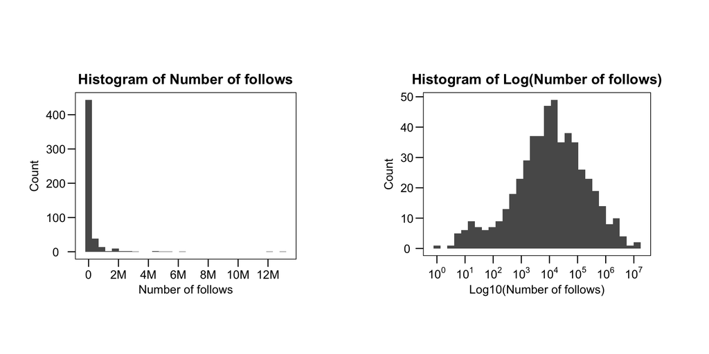

```r
library(ggplot2)
library(ggthemes)
library(scales)
library(grid)
library(dplyr)
library(gridExtra)
library(ggpubr)

NG_list |>
  ggplot(aes(x=followers)) +
  geom_histogram(bins = 30) +
  theme_par() +
  scale_x_continuous(n.breaks=10, labels = label_number(scale_cut = cut_short_scale())) +
  labs(x="Number of follows", y="Count", title="Histogram of Number of follows") -> p1

NG_list |>
  ggplot(aes(x=followers)) +
  geom_histogram(bins = 30) +
  theme_par() +
  scale_x_log10(n.breaks=10,
                labels = scales::label_log()) +
  labs(x="Log10(Number of follows)", y="Count", title="Histogram of Log(Number of follows)") -> p2

grid.arrange(p1, p2, ncol=2)
```